# Understanding routes of nanomaterial toxicity in exposed organisms

https://github.com/Jai906/Amos_ENV872_FinalProject.git

Jaleesia Amos

# Rationale and Research Question

Nanomaterials can be found in a broad range of consumer products due to their unique properties which separates them from their bulk counter parts. Most consumers will be exposed to nanomaterials according to what they eat and touch. For example, the food industry has found multiple uses for nanomaterials including as packaging and food additives (Mitrano 2015). In instances where the nanomaterial is embedded in the packaging, the nanomaterial can leach out of the packaging and into food. More specifically, nanosilver has many legitimate antimicrobial uses when incorporated into clothing and can also be found in beauty products as a treatment for acne (Reed 2016). These examples represent dermal and oral human exposures to the nanomaterial component of the composite material. Nanomaterials not only pose potential risks to consumers, but also to the environment.

Environmental exposures to nanomaterials can occur through intentional and unintentional occurrences. Nanomaterials are able to be move through environmental compartments that their bulk counterparts are excluded from due to their size. Nanomaterials therefore present an opportunity to address many of the oncoming issues in food security. Nano-agriculture is a growing field in which nanomaterials are engineered for targeted delivery and specified purposes (Lowry 2019). As previously mentioned, nanomaterials are added to a wide range of consumer products. These nano-enabled products can break down in the environment when they are not properly disposed of, or released into our water supply. Break down of nano-enabled products represents unintentional environmental exposures.

The route of nanomaterial exposure for both humans and environmental organisms frequently depends upon the intended use of nano-enabled products, the improper disposal of nanomaterials, or the intentional use nanomaterials in agriculture. Therefore, this project is focused on one main goal: determining if the exposure route impacts the fate of the nanomaterial in an organism. In this case, the fate will be determined by the organ where the nanomaterial is found.

# Dataset Information

The Center for the Environmental Implications of Nano Technology (CEINT) at Duke University developed the NanoInformatics Knowledge Commons (NIKC) Database as a repository for pristine nanomaterial toxicity data. The database was curated by the author and was intended to be used by regulatory agencies to estimate toxicity responses to nanomaterials from composite products. The NIKC database has a unique data organization structure specifically designed to follow the transformational changes of nanomaterials in different media. This structure was necessary as nanomaterial transformations also change their properties and therefore their toxicity.

Data curated into the database was procured from published literature. Where each individual dataset of the collective NIKC dataset is represented by the digital object identifier (DOI) to redirect users to the original published source. It is necessary to briefly describe the columns of the dataset to understand the wrangling process discussed later. Since the NIKC database was built to store a variety of toxicity data, the columns or variables are not predescribed like previous datasets reviewed throughout the course.

‘datasetId’ column: list the DOI of the original data points. ‘measurementType’ column: where the data is categorized into NIKC specific categories (figure 1). ‘parameter’ column: the traditional ‘variable’. For example, “nanomaterial”, or “organ” ‘parameterText’: describes the variable in the parameter column. For example, “multi-walled carbon nanotubes” to describe the “nanomaterial” and “liver” describes the “organ”.

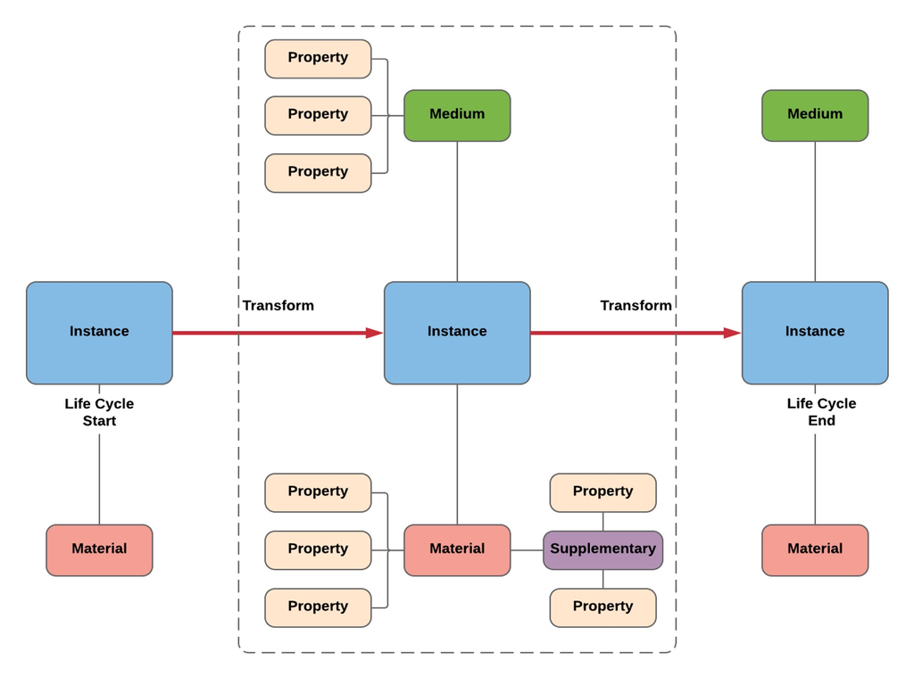

Figure 1. NIKC Instance structure

# Exploratory Analysis of Raw Dataset

Below is an overview of the NIKC database.

```
## Rows: 35,709
## Columns: 27
## $ datasetId                 <fct> 10.1016/j.toxlet.2015.07.001, 10.1016/j.toxl…
## $ measurementId             <int> 1, 2, 3, 4, 5, 6, 7, 8, 9, 10, 11, 12, 13, 1…
## $ measurementType           <fct> Instance, Material, Property, Property, Prop…
## $ referencingId             <int> NA, 1, 2, 2, 2, 2, 2, NA, 8, 9, 8, 11, 11, 1…
## $ sourceDoi                 <fct> , , , , , , , , , , , , , , , , , , , , , , …
## $ sourceId                  <int> NA, NA, NA, NA, NA, NA, NA, NA, NA, NA, NA, …
## $ timeRelative              <dbl> NA, NA, NA, NA, NA, NA, NA, NA, NA, NA, NA, …
## $ timeUnit                  <fct> , , , , , , , , , , , , , , , , , , , , , , …
## $ timeAbsolute              <lgl> NA, NA, NA, NA, NA, NA, NA, NA, NA, NA, NA, …
## $ parameter                 <fct> , core component, Physical State, Supplier, …
## $ inheritId                 <int> NA, NA, NA, NA, NA, NA, NA, NA, NA, NA, NA, …
## $ parameterDescription      <fct> , Reported by Experimenter, Reported by Expe…
## $ parameterDataType         <fct> , Text, Text, Text, Text, Numeric, Numeric, …
## $ parameterText             <fct> "", "silver nanoparticle", "Powder", "PPG Eu…
## $ parameterStatistics       <fct> , , , , , , mean, , , , , , , , , , , , , , …
## $ parameterNumeric          <fct> "", "", "", "", "", "25", "85", "", "", "0.9…
## $ parameterNumericOperator  <fct> , , , , , =, =, , , =, , , =, , =, =, =, =, …
## $ parameterUnit             <fct> , , , , , nanometer, nanometer, , , percent,…
## $ parameterUncertaintyType  <fct> , , , , , , range, , , , , , , , , , , , , ,…
## $ parameterUncertaintyLower <fct> "", "", "", "", "", "", "80", "", "", "", ""…
## $ parameterUncertaintyUpper <fct> "", "", "", "", "", "", "90", "", "", "", ""…
## $ parameterUncertaintyUnit  <fct> , , , , , , nanometer, , , , , , , , , , , ,…
## $ ownerGroup                <fct> [], [], [], [], [], [], [], [], [], [], [], …
## $ protocolId                <fct> "[]", "[]", "[]", "[]", "[\"1008\"]", "[\"10…
## $ instrumentId              <fct> "[]", "[]", "[]", "[]", "[\"10010\"]", "[\"1…
## $ X                         <lgl> NA, NA, NA, NA, NA, NA, NA, NA, NA, NA, NA, …
## $ X.1                       <lgl> NA, NA, NA, NA, NA, NA, NA, NA, NA, NA, NA, …
```

# Data Wrangling Process

The main question of this analysis is to determine if the route of exposure impacts the internal fate of the nanomaterial in an organism. Since the collective NIKC dataset consists of individual datasets addressing various research questions, it was necessary to wrangle the dataset to find the appropriate data points The data wrangling process occurred in four steps.

Step one: Identify which datasets recorder the ‘exposure route of administration’ and eliminate exposure routes classified as ‘dispersion’. Dispersion studies indicate cell line exposures, or not the whole organism. Please note, the returned exposure routes list from this step is larger than the finalized exposure routes list. This is because some routes were combined (i.e. ‘oropharyngeal aspiration’ and ‘Oropharyngeal aspiration’). See table 1 for final list of exposure routes.

```
##  [1] Oropharyngeal aspiration
##  [2] Intranasal administration
##  [3] single i.v. tail vein injection
##  [4] Intravenous
##  [5] intratracheal instillation
##  [6] Gavage
##  [7] placed posterior in the throat and the tongue held until the suspension was aspirated into the lungs
##  [8] instilled into the trachea using a 18G indwelling needle
##  [9] Microinjection
## [10] Microangiography
## [11] Diet
## [12] semi-static
## [13] pharyngeal aspiration
## [14] oropharyngeal aspiration
## [15] intratracheal
## [16] Intraperitoneal injection
## [17] Inhalation
## [18] Intratracheal instillation
## [19] inhalation
## [20] pharyngeal aspiration
## [21] Pharyngeal aspiration
## 938 Levels:  ... Yangzhou University Comparative Medicine Center
```

```
##  [1] 10.1016/j.toxlet.2015.07.001  10.1016/j.ntt.2015.08.006
##  [3] 10.1016/j.toxlet.2008.07.020  10.1016/j.carbon.2007.03.035
##  [5] 10.1016/j.taap.2007.03.018    10.1016/j.tox.2010.07.021
##  [7] 10.1016/j.taap.2008.12.006    10.3109/17435390.2010.502978
##  [9] 10.1016/j.aquatox.2007.02.003 10.1021/es4046023
## [11] 10.2147/IJN.S123345           10.1016/j.tox.2009.10.017
## [13] 10.1002/smll.201301597        10.1186/s12989-014-0052-6
## [15] 10.3390/nano7120441           10.1016/j.etp.2014.09.005
## [17] 10.3109/17435390.2012.719649  10.1186/1743-8977-10-33
## [19] 10.1186/1743-8977-8-24        10.1021/nn503887r
## [21] 10.1093/carcin/bgm243         10.1093/toxsci/kfp247
## [23] 10.1007/s10517-015-2835-7     10.1093/toxsci/kfs172
## [25] 10.3109/17435390.2014.933903  10.3109/17435390.2013.779757
## [27] 10.1177/0192623317732303      10.1016/j.bbrc.2015.01.130
## 162 Levels: 10.1002/adhm.201701313 10.1002/adhm.201701313  ... 10.3967/bes2014.103
```

```
##  [1] 10.1016/j.toxlet.2015.07.001  10.1016/j.ntt.2015.08.006
##  [3] 10.1016/j.toxlet.2008.07.020  10.1016/j.carbon.2007.03.035
##  [5] 10.1016/j.taap.2007.03.018    10.1016/j.tox.2010.07.021
##  [7] 10.1016/j.taap.2008.12.006    10.3109/17435390.2010.502978
##  [9] 10.1016/j.aquatox.2007.02.003 10.1021/es4046023
## [11] 10.2147/IJN.S123345           10.1016/j.tox.2009.10.017
## [13] 10.1002/smll.201301597        10.1186/s12989-014-0052-6
## [15] 10.3390/nano7120441           10.1016/j.etp.2014.09.005
## [17] 10.3109/17435390.2012.719649  10.1186/1743-8977-10-33
## [19] 10.1186/1743-8977-8-24        10.1021/nn503887r
## [21] 10.1093/carcin/bgm243         10.1093/toxsci/kfp247
## [23] 10.1007/s10517-015-2835-7     10.1093/toxsci/kfs172
## [25] 10.3109/17435390.2014.933903  10.3109/17435390.2013.779757
## [27] 10.1177/0192623317732303      10.1016/j.bbrc.2015.01.130
## 162 Levels: 10.1002/adhm.201701313 10.1002/adhm.201701313  ... 10.3967/bes2014.103
```

```
       Table 1: Final exposure routes
```

[output not shown]

Step two: Identify which organs were recorded in the dataset. Please note, the returned organs list from this step is larger than the finalized organ list. This is because some individual organs were combined (i.e. ‘cortex’, ‘hippocampus’, ‘lateral ventricles’ are parts of the brain). See table 2 for the final list of organs.

```
##  [1] Lung               Cortex             hippocampus        Spleen
##  [5] Liver              Choroid Plexus     Lateral Ventricles Hippocampus
##  [9] Brain              Lymphoid tissue    Stomach            Small Intestine
## [13] Large Intestine    Interstitium       Lymphoid Tissue    Gill
## [17] Intestine
## 938 Levels:  ... Yangzhou University Comparative Medicine Center
```

```
## factor(0)
## 938 Levels:  ... Yangzhou University Comparative Medicine Center
```

|  | Table 2: Final organs lists |
| --- | --- |
| 1 | Brain |
| 2 | Gill |
| 3 | Intestines |
| 4 | Liver |
| 5 | Lung |
| 6 | Spleen |
| 7 | Stomach |

Step three: Determine which exposure routes are linked to which organs.

```
##  [1] 10.1016/j.toxlet.2015.07.001  10.1016/j.ntt.2015.08.006
##  [3] 10.1016/j.toxlet.2008.07.020  10.1016/j.carbon.2007.03.035
##  [5] 10.1016/j.taap.2007.03.018    10.1016/j.tox.2010.07.021
##  [7] 10.1016/j.aquatox.2007.02.003 10.1016/j.tox.2009.10.017
##  [9] 10.1002/smll.201301597        10.3390/nano7120441
## [11] 10.3109/17435390.2012.719649  10.1186/1743-8977-10-33
## [13] 10.1186/1743-8977-8-24        10.1093/toxsci/kfs172
## [15] 10.3109/17435390.2014.933903  10.1177/0192623317732303
## 162 Levels: 10.1002/adhm.201701313 10.1002/adhm.201701313  ... 10.3967/bes2014.103
```

```
##  [1] 10.1016/j.toxlet.2015.07.001  10.1016/j.ntt.2015.08.006
##  [3] 10.1016/j.toxlet.2008.07.020  10.1016/j.carbon.2007.03.035
##  [5] 10.1016/j.taap.2007.03.018    10.1016/j.tox.2010.07.021
##  [7] 10.1016/j.aquatox.2007.02.003 10.3390/nano7120441
##  [9] 10.3109/17435390.2012.719649  10.1186/1743-8977-10-33
## [11] 10.1093/toxsci/kfs172         10.3109/17435390.2014.933903
## [13] 10.1016/j.bbrc.2015.01.130
## 162 Levels: 10.1002/adhm.201701313 10.1002/adhm.201701313  ... 10.3967/bes2014.103
```

```
##  [1] 10.1016/j.toxlet.2015.07.001  10.1016/j.ntt.2015.08.006
##  [3] 10.1016/j.toxlet.2008.07.020  10.1016/j.carbon.2007.03.035
##  [5] 10.1016/j.taap.2007.03.018    10.1016/j.tox.2010.07.021
##  [7] 10.1016/j.taap.2008.12.006    10.1016/j.aquatox.2007.02.003
##  [9] 10.2147/IJN.S123345           10.3390/nano7120441
## [11] 10.3109/17435390.2012.719649  10.1186/1743-8977-10-33
## [13] 10.1093/toxsci/kfs172         10.3109/17435390.2014.933903
## 162 Levels: 10.1002/adhm.201701313 10.1002/adhm.201701313  ... 10.3967/bes2014.103
```

Step four: Create a data frame with nano-fate information.

# Analysis

## Question 1: <Does the exposure route impact the fate of the nanomaterial in an organism?>

Since the objective is observe the flow of nanomaterials in an organism to it’s fate, it was decided that a flow diagram was most appropriate to address the research question. As this is an individual project and is addressing one main research question an additional challenge was taken on to create a diagram not previously reviewed in the course (Holtz 2023).

[interactive chart not shown]

Figure 2. Nanomaterial organ fate based on exposure route

# Summary and Conclusions

The Sankey Diagram illustrating the fate of the nanomaterial by exposure route indicates that the exposure does impact which organ the nanomaterial is fated. For example, nanomaterials that are introduced into the organism intravenously are found in the largest variety of organs. This is important to note as nanomaterials are also used for biomedical innovations as diagnosis and medication delivery methods.

Gavage is a method used to insert nanomaterials directly into the gut to ensure nanomaterial delivery, and yet none of the nanomaterials inserted via gavage are found in the stomach.

# References

<Amos, J. D. et al. The NanoInformatics Knowledge Commons: Capturing spatial and temporal nanomaterial transformations in diverse systems. NanoImpact 23, 100331 (2021).>

<Lowry, G. V., Avellan, A. & Gilbertson, L. M. Opportunities and challenges for nanotechnology in the agri-tech revolution. Nat. Nanotechnol. 14, 517-522 (2019). >

<Mitrano, D. M., Motellier, S., Clavaguera, S. & Nowack, B. Review of nanomaterial aging and transformations through the life cycle of nano-enhanced products. Environment International 77, 132-147 (2015).>

<Reed, R. B. et al. Potential Environmental Impacts and Antimicrobial Efficacy of Silver- and Nanosilver-Containing Textiles. Environmental Science & Technology 50, 4018-4026 (2016).>

<Holtz, Yan. ‘https://r-graph-gallery.com/about.html’>